# Time Series Homework: Chapter 3 Lesson 3

```r
pacman::p_load(
  tidyverse,  # ggplot, mutate(), cleaning...
  tsibble,    # as_tsibble()
  fable,      # model(...), forecast(), tidy(), glance()...
  feasts,     # ACF(), PACF()
  ggtime,     # autoplot() for tsibbles
  rio,        # import()
  pander,     # pander() markdown tables
  patchwork   # + and / for ggplots
)
```

## Data

```r
df <- rio::import("https://byuistats.github.io/timeseries/data/ILLNESS_CDCWONDER.csv") |>
  filter(`ICD Sub-Chapter Code` == "X60-X84")|>
  mutate(yearmonth = yearmonth(Date))

df2 <- read_csv("https://byuistats.github.io/timeseries/data/POPTHM.csv") |>
  mutate(yearmonth = yearmonth(observation_date))

illness <- df |>
  left_join(df2, by="yearmonth") |>
  mutate(`Deaths per 100000` = (Deaths/POPTHM)*100000) |>
  select(-c(observation_date)) |>
  filter(Year <= 2019)
```

## A Note Before Starting, Please Read

The data we will be looking at today covers a topic of deaths due to self harm. This is a incredibly serious and heavy topic and we would be remissed to not include some message at the beginning of this. People struggle with self harm and suicide due to a variety of different reasons. It is important to remember the following teachings and doctrines of the Church of Jesus Christ of Latter-Day Saints when approaching this topic:

- Mortal life is a precious gift that should be valued and protected (see D&C 18:10)
- When someone takes their own life, only God is able to judge their thoughts, their actions and their level of accountability. Suicide need not be the defining characteristic of an individual’s eternal life (see 1 Samuel 16:7)
- Through His Atonement, Jesus Christ experienced the fullness of mortal challenges so He could know “how to succor his people according to their infirmities” (Alma 7:11-13)

If you are struggling with thoughts of suicide or self harm, please know this. The world is better with you in it. We love you and want you to be here, and God loves you with an eternal love. You are not the only person who has struggled with this and there is hope and healing ahead. Please reach out to the Lord, those you trust, and the suicide prevention hotline (found by calling 988). Click [here](https://www.byui.edu/counseling-center/emergency-contact) for additional resources from BYU-Idaho.

If you know of someone who is struggling, [here](https://www.byui.edu/human-resources/0000018d-9fb8-dfac-afad-9ff9fb6d0000) is a good video with advice. As well the Church has additional resources that can be found in Gospel Library by going to the Life Help section under suicide.

## Questions

### Question 1 - Context and Measurement (10 points)

The first part of any time series analysis is context. You cannot properly analyze data without knowing what the data is measuring. Without context, the most simple features of data can be obscure and inscrutable. This homework assignment will center around the series below.

Please research the time series. In the spaces below, give the data collection process, unit of analysis, and meaning of each observation for the series.

#### **US Self Harm**

[CDC Website](https://wonder.cdc.gov/wonder/help/ucd.html#)

**NoteAnswer**

**Description:** The CDC Wonder data set contains mortality data for many different illnesses and afflictions. This data has been limited to their self harm data, which related to deaths caused when a person takes their own life. As of 2001 that now includes those who lose their life committing acts of terrorism and as of 2014 includes about 42% of cases previously labeled as accidental discharge of a firearm.

**Data Collection Process:** The data is collected monthly by the CDC going through the state registries and adding the information to the National Vital Statistics. Each death certificate has a primary cause of death, as well as up to 20 other additional causes.

**Unit of Analysis:** The unit of analysis is deaths per 100,000 due to suicide and self harm in the United States.

**Meaning of Each Observation:** Each monthly observation in the series reflects how many people out of 100,000 have died due to self harm that month.

### Question 2 - Additive Holt-Winters Forecasting (30 points)

This series imported above has not been seasonally adjusted.

##### a) Please use the Holt-Winters smoothing method to the series.

**NoteAnswer**

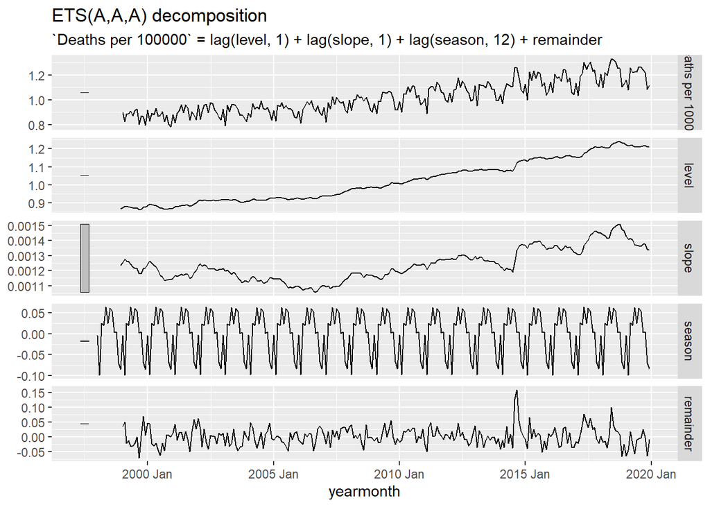

```r
illness_ts <- illness |>
  as_tsibble()

illness_hw <- illness_ts |>
  model(Additive = ETS(
    `Deaths per 100000` ~
      trend("A", alpha = 0.15, beta = 0.0005) +
      error("A") +
      season("A", gamma = 0.01),
    opt_crit = "amse",
    nmse = 1
  ))

autoplot(components(illness_hw))
```

**Clean**

```r
# Display model parameters
tidy(illness_hw) |> select(!.model) |> head(3) |> pander()
```

| term | estimate |
| --- | --- |
| alpha | 0.15 |
| beta | 5e-04 |
| gamma | 0.01 |

```r
# Display fit statistics
glance(illness_hw) |> select(!.model) |> pander()
```

| sigma2 | log_lik | AIC | AICc | BIC | MSE | AMSE | MAE |
| --- | --- | --- | --- | --- | --- | --- | --- |
| 0.001057 | 174.9 | -321.8 | -320 | -272.4 | 0.0009903 | 0.0009903 | 0.02376 |

Tip: Use `?fable` or look at the [documentation](https://fable.tidyverts.org/reference/index.html) to find new functions you can use.

**Decent**

```r
report(illness_hw)
```

```
Series: Deaths per 100000
Model: ETS(A,A,A)
  Smoothing parameters:
    alpha = 0.15
    beta  = 5e-04
    gamma = 0.01

  Initial states:
      l[0]        b[0]       s[0]       s[-1]       s[-2]       s[-3]
 0.8666982 0.001234788 -0.0845776 -0.06966815 0.004277882 0.003174214
      s[-4]      s[-5]      s[-6]     s[-7]      s[-8]      s[-9]      s[-10]
 0.05430962 0.06115529 0.02480376 0.0641101 0.02041718 0.02510358 -0.09877403
       s[-11]
 -0.004331844

  sigma^2:  0.0011

      AIC      AICc       BIC
-321.7869 -320.0147 -272.3749
```

**In the Weeds**

```r
# Display model parameters
params <- illness_hw$Additive[[1]]$fit$par
pander(tibble(
  Term = params$term,
  Estimate = params$estimate
))
```

| Term | Estimate |
| --- | --- |
| alpha | 0.15 |
| beta | 5e-04 |
| gamma | 0.01 |
| l | 0.8667 |
| b | 0.001235 |
| s0 | -0.08458 |
| s1 | -0.06967 |
| s2 | 0.004278 |
| s3 | 0.003174 |
| s4 | 0.05431 |
| s5 | 0.06116 |
| s6 | 0.0248 |
| s7 | 0.06411 |
| s8 | 0.02042 |
| s9 | 0.0251 |
| s10 | -0.09877 |

```r
# Display fit statistics
pander(illness_hw$Additive[[1]]$fit$fit)
```

| sigma2 | log_lik | AIC | AICc | BIC | MSE | AMSE | MAE |
| --- | --- | --- | --- | --- | --- | --- | --- |
| 0.001057 | 174.9 | -321.8 | -320 | -272.4 | 0.0009903 | 0.0009903 | 0.02376 |

If you want to have fun exploring, run `illness_hw$Additive[[1]]`

Then use class() and str() as you descend deeper

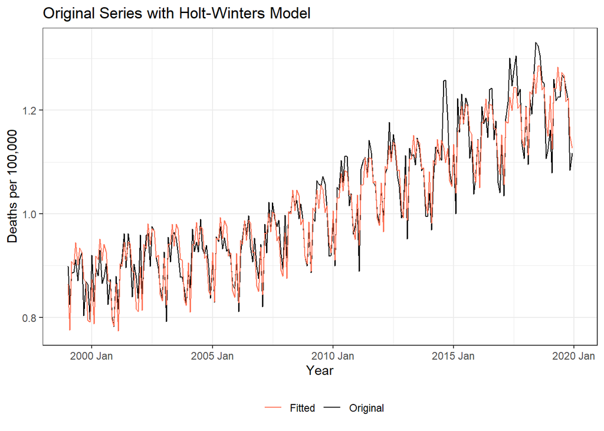

```r
illness_fitted <- augment(illness_hw)

ggplot(illness_fitted, aes(x = yearmonth, y = `Deaths per 100000`)) +
  geom_line(aes(color = "Original")) +
  geom_line(aes(y = .fitted, color = "Fitted")) +
  scale_color_manual(values = c("Original" = "black", "Fitted" = "coral1")) +
  labs(
    x = "Year",
    y = "Deaths per 100,000",
    color = "",
    title = "Original Series with Holt-Winters Model") +
  theme_bw() +
  theme(legend.position = "bottom")
```

##### b) What parameters values did you choose for $\alpha$, $\beta$, and $\gamma$. Justify your choice.

**NoteAnswer**

An α of 0.15 was chosen because the underlying baseline rate of mortality is expected to be relatively consistent, requiring the model to smooth out short-term fluctuations rather than overreact to them. Similarly, a very small β of 0.0005 was implemented, reflecting the assumption that any trend in mortality rates is established over long periods and should not be heavily influenced by recent, potentially noisy observations, thereby prioritizing historical trend stability. A small γ of 0.01 was selected because seasonal patterns in such data are typically stable and evolve slowly, meaning the model should place less emphasis on current observations when updating its seasonal components. Collectively, these relatively small parameter values ensure the model produces smooth and stable estimates of the level, trend, and seasonality, making it robust to noise and suitable for phenomena like public health trends that generally exhibit gradual changes.

##### c) Please plot the Holt-Winters forecast of the series for the next 24 months superimposed against the original series. Please see [Figure 7](https://byuistats.github.io/timeseries/chapter_3_lesson_4.html#fig-crime-hw-forecast) in Chapter 3: Lesson 3

**NoteAnswer**

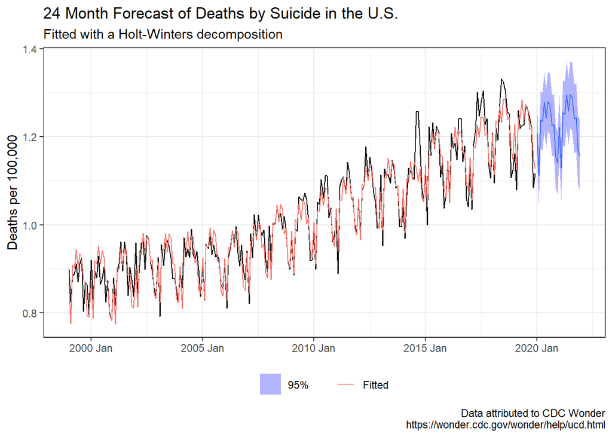

```r
# Create a forecast "fable"
#   (like a tsibble for forecasts, with extra stuff like confidence intervals)
illness_forecast <- forecast(illness_hw, h = "24 months")

# Create a tsibble with fitted values (.fitted) from holt winters model
illness_fitted <- augment(illness_hw)

# Plot   blue line,     black line, blue band
autoplot(illness_forecast, illness_ts, level = 95) +
  geom_line(
    data = illness_fitted,
    aes(y = .fitted, color = "Fitted") # orange line
  ) +
  theme_bw() +
  labs(
    title = "24 Month Forecast of Deaths by Suicide in the U.S.",
    subtitle = "Fitted with a Holt-Winters decomposition",
    x = NULL,
    y = "Deaths per 100,000",
    caption = "Data attributed to CDC Wonder
               https://wonder.cdc.gov/wonder/help/ucd.html"
  ) +
  theme(
    legend.position = "bottom",
    legend.title = element_blank()
  )
```

### Question 3 - Additive Holt-Winters Forecasting: Evaluation (20 points)

##### a) The data has been filtered to stop around 2019. Bellow we have the complete series, please don’t look at it until you have reached this point in the homework. Compare your forecasting work with with the actual realization of the series. What lessons about forecasting can you learn from the occurrence of [Gray Rhino](https://chatgpt.com/share/6712c9e5-4f58-8005-888d-acae9895bd05) events like a pandemic?

**NoteAnswer**

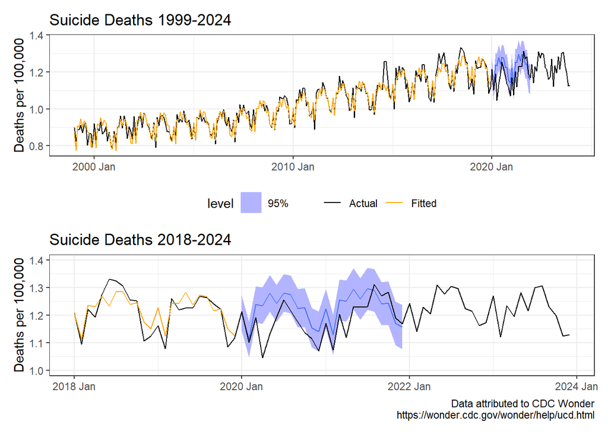

```r
# Import all data
illness_current <- df |>
  left_join(df2, by="yearmonth") |>
  mutate(`Deaths per 100000` = (Deaths / POPTHM) * 100000) |>
  select(-c(observation_date)) |>
  as_tsibble()

# Zoomed out view
far <- autoplot(illness_forecast, level = 95) + # blue line
  geom_line(
    data = illness_current,
    aes(x = yearmonth, y = `Deaths per 100000`, color = "Actual") # black line
  ) +
  geom_line(
    data = illness_fitted,  # convert to tsibble with .fitted column
    aes(y = .fitted, color = "Fitted"), # orange line
  ) +
  scale_color_manual(values = c("Fitted" = "orange", "Actual" = "black")) +
  labs(
    x = NULL,
    y = "Deaths per 100,000",
    color = "",
    title = "Suicide Deaths 1999-2024"
  ) +
  theme_bw() +
  theme(legend.position = "bottom")

# Zoomed in view
close <- autoplot(illness_forecast, level = 95) +
  geom_line(
    data = illness_current,
    aes(x = yearmonth, y = `Deaths per 100000`, color = "Actual")
  ) +
  geom_line(
    data = illness_fitted,
    aes(y = .fitted, color = "Fitted")
  ) +
  scale_color_manual(values = c("Fitted" = "orange", "Actual" = "black")) +
  scale_x_yearmonth(limits = c(ym("2018-01"), ym("2023-12"))) +
  scale_y_continuous(limits = c(1, 1.4)) +
  labs(
    x = NULL,
    y = "Deaths per 100,000",
    color = "",
    title = "Suicide Deaths 2018-2024",
    caption = "Data attributed to CDC Wonder
               https://wonder.cdc.gov/wonder/help/ucd.html"
  ) +
  theme_bw() +
  theme(legend.position = "none")

# Put it together and what do you got? bippity-boppity-view
far / close
```

We can see that the forecast is fairly higher than what actually occurred in the data. This highlights the grey rhino effect— a high-impact, foreseeable event often underestimated in risk assessment. While the pandemic’s risks were known, they were largely ignored in routine forecasts, underscoring a key limitation: standard models often fail to account for foreseeable shocks. This gap between forecasted and actual values emphasizes the need for forecasting frameworks to integrate “grey rhino” scenarios to better prepare for major, probable risks.

### Rubric

[output not shown]